While preparing a course about version control and Git, I wanted to know about the adoption of Version Control Systems (VCS) in well-known open source projects over time.

## Gathering the data

As I could not find such data online, I gathered it manually. Please note that the data likely contains mistakes as the process is tedious and error-prone — feel free to contribute via issues/[PRs](https://github.com/mpoquet/vcs-popularity/pulls) if you find any error or want to add data about some project.

Only few projects have documented their successive VCS migrations — good examples of well-documented projects are Python (cf. [PEP 347](https://www.python.org/dev/peps/pep-0347/), [PEP 385](https://www.python.org/dev/peps/pep-0385/), [PEP 512](https://www.python.org/dev/peps/pep-0512/)) and Linux (cf. [A Short History of Git](https://git-scm.com/book/en/v2/Getting-Started-A-Short-History-of-Git)).

I gathered data manually about most other projects by doing some archeology in their commit history, their release notes and their dev/commit mailing lists. If you ever need to do such archeology, I found these hints especially useful:

- History of VCS-specific files (*e.g.*, `.gitignore`, `.bzrignore`, `.cvsignore`). Note that reading commit messages is very important about these files, as some of them have a shared commit history across several VCS (*e.g.*, `.bzrignore` file moved to `.gitignore`).
- Commit format. Migrations from SVN to git via `git-svn` seems to add `git-svn` info in commits. Migrations from `RCS` seems to add `Entering into RCS` commits.
- Migrations from a distributed VCS to git are harder to detect. I dated most of these thanks to the project documentation/news/dev mailing lists (e.g., [GCC’s Moving to Git](https://gcc.gnu.org/wiki/GitConversion)).

## Visualization

Visualization scripts to reproduce this analysis are available on the [vcs-popularity repository](https://github.com/mpoquet/vcs-popularity). Here is a raw view of the gathered data.

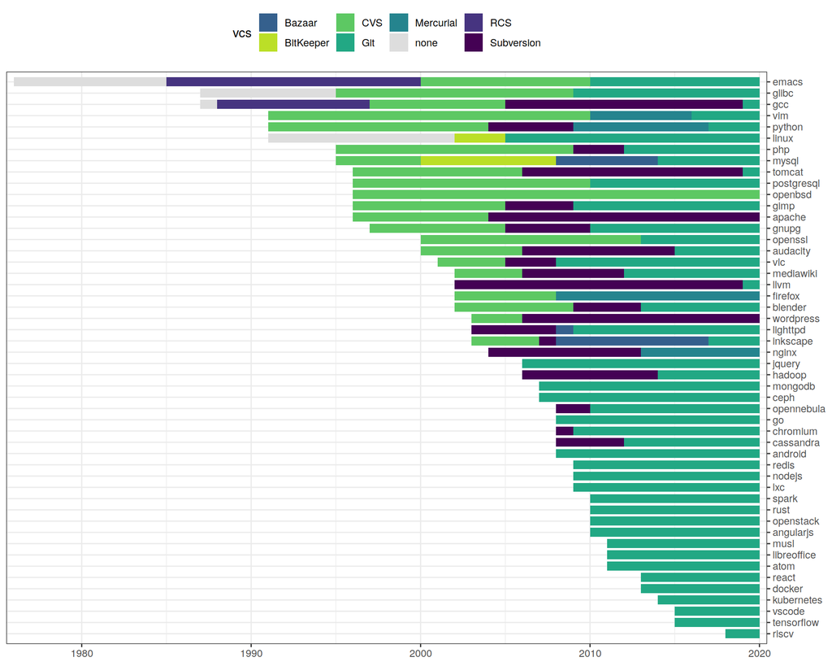

Here is the number of projects using each VCS over time.

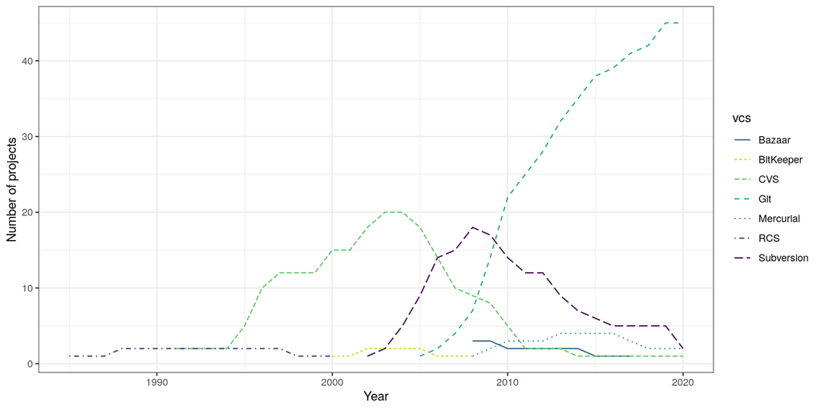

## Conclusion

As expected, Git is the ultra-dominant VCS today. Git is the default VCS choice for most projects since 2008, and most older projects have switched to Git as of 2020.

This popularity is unlikely to decline soon, as most accessible online services to host projects only support Git now.

- Several VCS can be used on SourceForge but most users fled from it since [SourceForge’s 2013-2015 adware/malware shenanigans](https://en.wikipedia.org/wiki/SourceForge#Controversies).
- Several VCS could be used on Google Code, but [Google Code closed in 2016](https://opensource.googleblog.com/2015/03/farewell-to-google-code.html).
- GitHub is by far the most popular today, and only proposes the Git VCS.
- GitLab’s popularity increases, and also only proposes the Git VCS. Moreover, GitLab is unlikely to vanish overnight since it is open source and quite simple to deploy on your own infrastructure.
- Even if Bitbucket only proposed the Mercurial VCS when it started in 2008, Git was introduced in 2011 and became so popular on the platform that [Bitbucket only proposes Git since July 2020](https://bitbucket.org/blog/sunsetting-mercurial-support-in-bitbucket).

Finally, the rise of continuous integration and DevOps methodologies promote VCS that integrate well with these practices — where Git seems to be one step ahead.

- GitLab is very convenient for such practice, as Gitlab CI is convenient for developers (clean syntax, controllable software environment, pleasant interface) and for administrators (versatile architecture). GitLab also has a Kubernetes integration.
- Popular external CI services are limited to Git, such as Travis or Circle CI — both can be plugged to either GitHub or Bitbucket, but these two platforms only support the Git VCS as of 2020.
- CI practice can of course be used on non-Git VCS. For example, Firefox uses continous integration with a Mercurial VCS, but this required Firefox developers to build their own CI stack (cf. [Firefox’s CI practice](https://developer.mozilla.org/en-US/docs/Mozilla/Continuous_integration), [Taskcluster](https://docs.taskcluster.net/docs)). Plugging any VCS to a dedicated test infrastructure (*e.g.*, Jenkins) is also possible. However, the lack of free online services to host the CI for non-Git projects makes it impractical for small/new projects, that do not have their own infrastructure nor the manpower to develop their own CI technology.